# Thera Bank Customer Churn Project

### Background & Context

Thera bank recently saw a steep decline in the number of users of their credit card, credit cards are a good source of income for banks because of different kinds of fees charged by the banks like annual fees, balance transfer fees, and cash advance fees, late payment fees, foreign transaction fees, and others. Some fees are charged on every user irrespective of usage, while others are charged under specified circumstances.

Customers’ leaving credit cards services would lead bank to loss, so the bank wants to analyze the data of customers’ and identify the customers who will leave their credit card services and reason for same – so that the bank could improve upon those areas

### Objective

The objective is to build a classification model to predict if a customer is going to churn or not

### Data Dictionary

- CLIENTNUM: Client number. Unique identifier for the customer holding the account
- Attrition_Flag: Internal event (customer activity) variable - if the account is closed then 1 else 0
- Customer_Age: Age in Years
- Gender: Gender of the account holder
- Dependent_count: Number of dependents
- Education_Level: Educational Qualification of the account holder
- Marital_Status: Marital Status of the account holder
- Income_Category: Annual Income Category of the account holder
- Card_Category: Type of Card
- Months_on_book: Period of relationship with the bank
- Total_Relationship_Count: Total no. of products held by the customer
- Months_Inactive_12_mon: No. of months inactive in the last 12 months
- Contacts_Count_12_mon: No. of Contacts in the last 12 months
- Credit_Limit: Credit Limit on the Credit Card
- Total_Revolving_Bal: Total Revolving Balance on the Credit Card
- Avg_Open_To_Buy: Open to Buy Credit Line (Average of last 12 months)
- Total_Amt_Chng_Q4_Q1: Change in Transaction Amount (Q4 over Q1)
- Total_Trans_Amt: Total Transaction Amount (Last 12 months)
- Total_Trans_Ct: Total Transaction Count (Last 12 months)
- Total_Ct_Chng_Q4_Q1: Change in Transaction Count (Q4 over Q1)
- Avg_Utilization_Ratio: Average Card Utilization Ratio

### 1.1 Load Libraries

```python
import warnings

warnings.filterwarnings("ignore")
# Libraries to help with reading and manipulating data
import pandas as pd
import numpy as np

# libaries to help with data visualization
%matplotlib inline
import matplotlib.pyplot as plt
import seaborn as sns

# Libraries to tune model, get different metric scores, and split data
from sklearn import metrics
from sklearn.model_selection import train_test_split, StratifiedKFold, cross_val_score
from sklearn.preprocessing import StandardScaler
from sklearn.model_selection import GridSearchCV, RandomizedSearchCV

from sklearn.impute import KNNImputer
from sklearn.pipeline import Pipeline, make_pipeline

#Libraries to help scale data
from sklearn.preprocessing import StandardScaler

#libraries to help with model building
from sklearn.linear_model import LogisticRegression
from sklearn.tree import DecisionTreeClassifier
from sklearn.ensemble import (
    AdaBoostClassifier,
    GradientBoostingClassifier,
    RandomForestClassifier,
    BaggingClassifier)
from xgboost import XGBClassifier

# library to help with imbalanced dataset
from imblearn.over_sampling import SMOTE
from imblearn.under_sampling import RandomUnderSampler
```

### 1.2. Import the dataset

```python
new_data  = pd.read_csv('BankChurners.csv') # Import the dataset named BankChurners.csv
data = new_data.copy()
data.head()  # view the first 5 rows of the data
```

|  | CLIENTNUM | Attrition_Flag | Customer_Age | Gender | Dependent_count | Education_Level | Marital_Status | Income_Category | Card_Category | Months_on_book | ... | Months_Inactive_12_mon | Contacts_Count_12_mon | Credit_Limit | Total_Revolving_Bal | Avg_Open_To_Buy | Total_Amt_Chng_Q4_Q1 | Total_Trans_Amt | Total_Trans_Ct | Total_Ct_Chng_Q4_Q1 | Avg_Utilization_Ratio |
| --- | --- | --- | --- | --- | --- | --- | --- | --- | --- | --- | --- | --- | --- | --- | --- | --- | --- | --- | --- | --- | --- |
| 0 | 768805383 | Existing Customer | 45 | M | 3 | High School | Married | $60K - $80K | Blue | 39 | ... | 1 | 3 | 12691.0 | 777 | 11914.0 | 1.335 | 1144 | 42 | 1.625 | 0.061 |
| 1 | 818770008 | Existing Customer | 49 | F | 5 | Graduate | Single | Less than $40K | Blue | 44 | ... | 1 | 2 | 8256.0 | 864 | 7392.0 | 1.541 | 1291 | 33 | 3.714 | 0.105 |
| 2 | 713982108 | Existing Customer | 51 | M | 3 | Graduate | Married | $80K - $120K | Blue | 36 | ... | 1 | 0 | 3418.0 | 0 | 3418.0 | 2.594 | 1887 | 20 | 2.333 | 0.000 |
| 3 | 769911858 | Existing Customer | 40 | F | 4 | High School | Unknown | Less than $40K | Blue | 34 | ... | 4 | 1 | 3313.0 | 2517 | 796.0 | 1.405 | 1171 | 20 | 2.333 | 0.760 |
| 4 | 709106358 | Existing Customer | 40 | M | 3 | Uneducated | Married | $60K - $80K | Blue | 21 | ... | 1 | 0 | 4716.0 | 0 | 4716.0 | 2.175 | 816 | 28 | 2.500 | 0.000 |

5 rows × 21 columns

### 1.3 Check the Dimension of data

```python
data.shape # Check the shape of the data
```

```
(10127, 21)
```

```python
# Check if all Client numbers are unique
data['CLIENTNUM'].nunique()
```

```
10127
```

### Observation

```python
# We will go ahead and drop this column as we won't be using it
data.drop(['CLIENTNUM'],axis=1,inplace=True)
```

### 1.4 Check the Information about the data

```python
pd.DataFrame(data.isnull().sum(), columns= ['Number of missing values']) # Number of missing values in the data
```

|  | Number of missing values |
| --- | --- |
| Attrition_Flag | 0 |
| Customer_Age | 0 |
| Gender | 0 |
| Dependent_count | 0 |
| Education_Level | 0 |
| Marital_Status | 0 |
| Income_Category | 0 |
| Card_Category | 0 |
| Months_on_book | 0 |
| Total_Relationship_Count | 0 |
| Months_Inactive_12_mon | 0 |
| Contacts_Count_12_mon | 0 |
| Credit_Limit | 0 |
| Total_Revolving_Bal | 0 |
| Avg_Open_To_Buy | 0 |
| Total_Amt_Chng_Q4_Q1 | 0 |
| Total_Trans_Amt | 0 |
| Total_Trans_Ct | 0 |
| Total_Ct_Chng_Q4_Q1 | 0 |
| Avg_Utilization_Ratio | 0 |

```python
data.info() # Check information on the data
```

```
<class 'pandas.core.frame.DataFrame'>
RangeIndex: 10127 entries, 0 to 10126
Data columns (total 20 columns):
 #   Column                    Non-Null Count  Dtype
---  ------                    --------------  -----
 0   Attrition_Flag            10127 non-null  object
 1   Customer_Age              10127 non-null  int64
 2   Gender                    10127 non-null  object
 3   Dependent_count           10127 non-null  int64
 4   Education_Level           10127 non-null  object
 5   Marital_Status            10127 non-null  object
 6   Income_Category           10127 non-null  object
 7   Card_Category             10127 non-null  object
 8   Months_on_book            10127 non-null  int64
 9   Total_Relationship_Count  10127 non-null  int64
 10  Months_Inactive_12_mon    10127 non-null  int64
 11  Contacts_Count_12_mon     10127 non-null  int64
 12  Credit_Limit              10127 non-null  float64
 13  Total_Revolving_Bal       10127 non-null  int64
 14  Avg_Open_To_Buy           10127 non-null  float64
 15  Total_Amt_Chng_Q4_Q1      10127 non-null  float64
 16  Total_Trans_Amt           10127 non-null  int64
 17  Total_Trans_Ct            10127 non-null  int64
 18  Total_Ct_Chng_Q4_Q1       10127 non-null  float64
 19  Avg_Utilization_Ratio     10127 non-null  float64
dtypes: float64(5), int64(9), object(6)
memory usage: 1.5+ MB
```

```python
data.nunique() # Check the number of Unique values in dataset
```

```
Attrition_Flag                 2
Customer_Age                  45
Gender                         2
Dependent_count                6
Education_Level                7
Marital_Status                 4
Income_Category                6
Card_Category                  4
Months_on_book                44
Total_Relationship_Count       6
Months_Inactive_12_mon         7
Contacts_Count_12_mon          7
Credit_Limit                6205
Total_Revolving_Bal         1974
Avg_Open_To_Buy             6813
Total_Amt_Chng_Q4_Q1        1158
Total_Trans_Amt             5033
Total_Trans_Ct               126
Total_Ct_Chng_Q4_Q1          830
Avg_Utilization_Ratio        964
dtype: int64
```

```python
data.describe().T # Five(5) number summary of the quantitative variables
```

|  | count | mean | std | min | 25% | 50% | 75% | max |
| --- | --- | --- | --- | --- | --- | --- | --- | --- |
| Customer_Age | 10127.0 | 46.325960 | 8.016814 | 26.0 | 41.000 | 46.000 | 52.000 | 73.000 |
| Dependent_count | 10127.0 | 2.346203 | 1.298908 | 0.0 | 1.000 | 2.000 | 3.000 | 5.000 |
| Months_on_book | 10127.0 | 35.928409 | 7.986416 | 13.0 | 31.000 | 36.000 | 40.000 | 56.000 |
| Total_Relationship_Count | 10127.0 | 3.812580 | 1.554408 | 1.0 | 3.000 | 4.000 | 5.000 | 6.000 |
| Months_Inactive_12_mon | 10127.0 | 2.341167 | 1.010622 | 0.0 | 2.000 | 2.000 | 3.000 | 6.000 |
| Contacts_Count_12_mon | 10127.0 | 2.455317 | 1.106225 | 0.0 | 2.000 | 2.000 | 3.000 | 6.000 |
| Credit_Limit | 10127.0 | 8631.953698 | 9088.776650 | 1438.3 | 2555.000 | 4549.000 | 11067.500 | 34516.000 |
| Total_Revolving_Bal | 10127.0 | 1162.814061 | 814.987335 | 0.0 | 359.000 | 1276.000 | 1784.000 | 2517.000 |
| Avg_Open_To_Buy | 10127.0 | 7469.139637 | 9090.685324 | 3.0 | 1324.500 | 3474.000 | 9859.000 | 34516.000 |
| Total_Amt_Chng_Q4_Q1 | 10127.0 | 0.759941 | 0.219207 | 0.0 | 0.631 | 0.736 | 0.859 | 3.397 |
| Total_Trans_Amt | 10127.0 | 4404.086304 | 3397.129254 | 510.0 | 2155.500 | 3899.000 | 4741.000 | 18484.000 |
| Total_Trans_Ct | 10127.0 | 64.858695 | 23.472570 | 10.0 | 45.000 | 67.000 | 81.000 | 139.000 |
| Total_Ct_Chng_Q4_Q1 | 10127.0 | 0.712222 | 0.238086 | 0.0 | 0.582 | 0.702 | 0.818 | 3.714 |
| Avg_Utilization_Ratio | 10127.0 | 0.274894 | 0.275691 | 0.0 | 0.023 | 0.176 | 0.503 | 0.999 |

```python
# Function to Calculate the Coefficient of Variation
def coef_var(col):
    return round(data[col].std()/data[col].mean() * 100, 3)

columns = ['Customer_Age','Dependent_count','Months_on_book','Total_Relationship_Count','Months_Inactive_12_mon',
          'Contacts_Count_12_mon','Credit_Limit','Total_Revolving_Bal','Avg_Open_To_Buy','Total_Amt_Chng_Q4_Q1',
           'Total_Trans_Amt','Total_Trans_Ct','Total_Ct_Chng_Q4_Q1','Avg_Utilization_Ratio']
for colname in columns:
    cf = coef_var(colname)
    print('The coefficient of variation for', colname, 'is :' , cf, '%')
```

```
The coefficient of variation for Customer_Age is : 17.305 %
The coefficient of variation for Dependent_count is : 55.362 %
The coefficient of variation for Months_on_book is : 22.229 %
The coefficient of variation for Total_Relationship_Count is : 40.77 %
The coefficient of variation for Months_Inactive_12_mon is : 43.167 %
The coefficient of variation for Contacts_Count_12_mon is : 45.054 %
The coefficient of variation for Credit_Limit is : 105.292 %
The coefficient of variation for Total_Revolving_Bal is : 70.088 %
The coefficient of variation for Avg_Open_To_Buy is : 121.71 %
The coefficient of variation for Total_Amt_Chng_Q4_Q1 is : 28.845 %
The coefficient of variation for Total_Trans_Amt is : 77.136 %
The coefficient of variation for Total_Trans_Ct is : 36.19 %
The coefficient of variation for Total_Ct_Chng_Q4_Q1 is : 33.429 %
The coefficient of variation for Avg_Utilization_Ratio is : 100.29 %
```

```python
def check_value_counts(col): # Function to check value_counts of variables
    print(data[col].value_counts())

for val in data.columns:
    check_value_counts(val)
    print('-'*35)
```

```
Existing Customer    8500
Attrited Customer    1627
Name: Attrition_Flag, dtype: int64
-----------------------------------
44    500
49    495
46    490
45    486
47    479
43    473
48    472
50    452
42    426
51    398
53    387
41    379
52    376
40    361
39    333
54    307
38    303
55    279
56    262
37    260
57    223
36    221
35    184
59    157
58    157
34    146
60    127
33    127
32    106
65    101
61     93
62     93
31     91
26     78
30     70
63     65
```

[output cut: 213 more lines]

```
Name: Total_Ct_Chng_Q4_Q1, Length: 830, dtype: int64
-----------------------------------
0.000    2470
0.073      44
0.057      33
0.048      32
0.060      30
         ...
0.929       1
0.874       1
0.995       1
0.011       1
0.985       1
Name: Avg_Utilization_Ratio, Length: 964, dtype: int64
-----------------------------------
```

### Observations

- There are 14 numerical and 6 object variables within this dataset
- The mean of 'Customer_Age', 'Dependent_count', 'Months_Inactive_12_mon', 'Contacts_Count_12_mon', 'Credit_Limit', 'Avg_Open_To_Buy', 'Total_Amt_Chng_Q4_Q1', 'Total_Trans_Amt', 'Total_Ct_Chng_Q4_Q1','Avg_Utilization_Ratio', are greater than the median which suggests a right skewed distribution.
- The coefficient of variation lets us know how spread out values are in relation to the mean. Most of our numerical variables have well spread out datapoints, however, 'Credit_Limit', 'Avg_Open_To_Buy', 'Avg_Utilization_Ratio' have coefficient of variations over 100% which suggests the existence of outliers within these variables.
- 'Attrition_Flag', 'Gender', 'Dependent_count','Education_Level', 'Marital_Status', 'Income_Category', 'Card_Category', 'Total_Relationship_Count', 'Months_Inactive_12_mon', 'Contacts_Count_12_mon', variables would need to be converted to category datatype as they contain finite number of possible values.
- The following columns, 'Education_Level', 'Marital_Status', 'Income_Category' have 'unknown' which also signify missing values. This would be treated using KNN algorithm

### 1.5 Data Pre-Processing & Feature Engineering

```python
#Convert object columns to category datatype
categories = ['Attrition_Flag', 'Gender', 'Dependent_count','Education_Level', 'Marital_Status', 'Income_Category',
              'Card_Category', 'Total_Relationship_Count', 'Months_Inactive_12_mon', 'Contacts_Count_12_mon']
data = data.apply(lambda col: col.astype('category') if col.name in categories else col)
```

```python
# Replace Unknown values with NaN
cols = ['Education_Level', 'Marital_Status', 'Income_Category']

for col in cols:
    data.loc[data[col] == 'Unknown', col] = np.nan
```

### 1.6 Exploratory Data Analysis (Univariate Analysis)

```python
# Function to create Histogram and Boxplot Visualizations
def hist_box(variable, bins, xlabel):
    plt.figure(figsize=(6,3)) # set the figure size
    sns.distplot(variable, bins=bins) # Plot the histogram

    plt.axvline(variable.mean(),color='green',label='Mean') # Draw lines on the plot for mean and median of the variable
    plt.axvline(variable.median(),color='blue',label='Median')

    plt.xlabel(xlabel) # label the x-axis
    plt.ylabel('Frequency') # label the y-axis
    plt.legend() # Plot the legend
    plt.title('Measure of Central Tendency and Dispersion') # Display plot title
    plt.show() # Display Plot

    plt.figure(figsize=(6,3)) # set the figure size
    sns.boxplot(variable) # Plot BoxPlot
```

### Visualization of Central Tendency and Dispersion Using Histogram & Boxplot (Customer_Age)

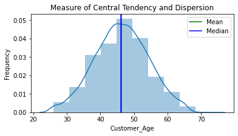

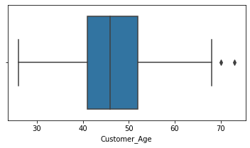

```python
hist_box(data['Customer_Age'], 10, 'Customer_Age')
```

### Observations

- The banks customer age variable has a normal-like distribution.
- There isn't much difference between the mean and median of the values
- The average age of a customer is 46 yrs
- Most customers are within the ages 41 and 52 yrs old

### Visualization of Central Tendency and Dispersion Using Histogram & Boxplot (Months_on_book)

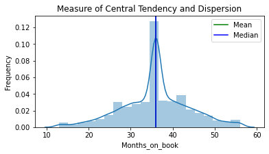

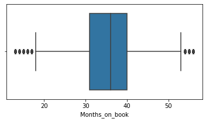

```python
hist_box(data['Months_on_book'], 20, 'Months_on_book')
```

### Observations

- On average, credit cards usually expire 3 years (36 months) after the card was issued. From the data, we can see that this assumption is valid as a large number of customers relationship with the bank lasts for about 36 months. This suggests that these customers do not renew their credit cards when it reaches expiration 3 years after issue.
- Most customers have a relationship with the bank for between 31 and 40 months.

### Visualization of Central Tendency and Dispersion Using Histogram & Boxplot (Credit_Limit)

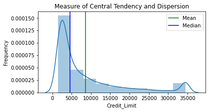

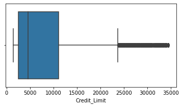

```python
hist_box(data['Credit_Limit'], 10, 'Credit_Limit')
```

### Visualization of Central Tendency and Dispersion Using Histogram & Boxplot (Total_Revolving_Bal)

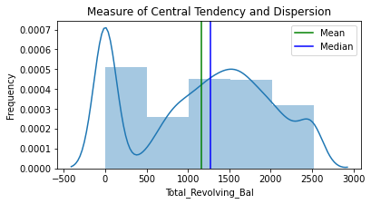

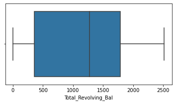

```python
hist_box(data['Total_Revolving_Bal'], 5, 'Total_Revolving_Bal')
```

### Visualization of Central Tendency and Dispersion Using Histogram & Boxplot (Avg_Open_To_Buy)

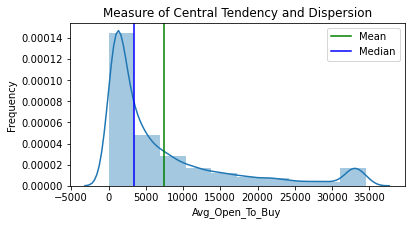

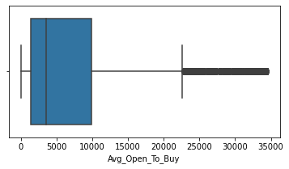

```python
hist_box(data['Avg_Open_To_Buy'], 10, 'Avg_Open_To_Buy')
```

### Visualization of Central Tendency and Dispersion Using Histogram & Boxplot (Total_Amt_Chng_Q4_Q1)

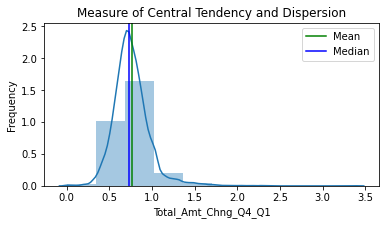

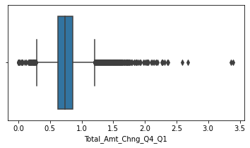

```python
hist_box(data['Total_Amt_Chng_Q4_Q1'], 10, 'Total_Amt_Chng_Q4_Q1')
```

### Visualization of Central Tendency and Dispersion Using Histogram & Boxplot (Total_Trans_Amt)

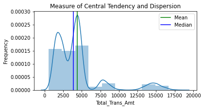

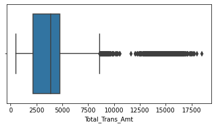

```python
hist_box(data['Total_Trans_Amt'], 10, 'Total_Trans_Amt')
```

### Visualization of Central Tendency and Dispersion Using Histogram & Boxplot (Total_Trans_Ct)

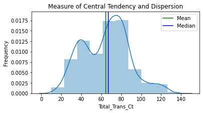

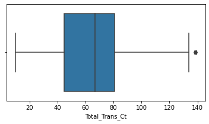

```python
hist_box(data['Total_Trans_Ct'], 10, 'Total_Trans_Ct')
```

### Visualization of Central Tendency and Dispersion Using Histogram & Boxplot (Total_Ct_Chng_Q4_Q1)

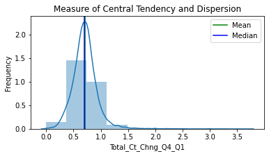

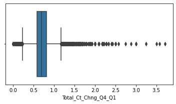

```python
hist_box(data['Total_Ct_Chng_Q4_Q1'], 10, 'Total_Ct_Chng_Q4_Q1')
```

### Visualization of Central Tendency and Dispersion Using Histogram & Boxplot (Avg_Utilization_Ratio)

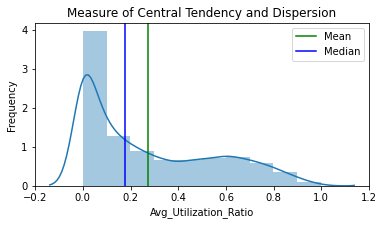

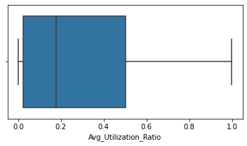

```python
hist_box(data['Avg_Utilization_Ratio'], 10, 'Avg_Utilization_Ratio')
```

### Observations

```python
# Function to create barplots that indicate percentage for each category.

def perc_on_bar(plot, feature):

    total = len(feature) # length of the column
    for p in ax.patches:
        percentage = '{:.1f}%'.format(100 * p.get_height()/total) # percentage of each class of the category
        x = p.get_x() + p.get_width() / 2 - 0.05 # width of the plot
        y = p.get_y() + p.get_height()           # hieght of the plot
        ax.annotate(percentage, (x, y), size = 12) # annotate the percantage
    plt.show() # show the plot
```

### Visualization of Categorical Variables Using Barplot (Attrition_Flag)

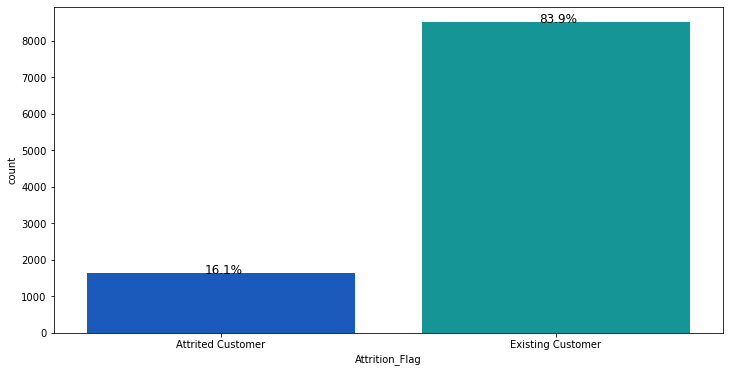

```python
# Plot barplot for Attrition_Flag Variable
plt.figure(figsize=(12,6)) # set the figure size
ax = sns.countplot(data['Attrition_Flag'],palette='winter')
perc_on_bar(ax,data['Attrition_Flag'])
```

### Observations

- 16% of Thera banks credit card customers attrited in the last 12 months
- As this is our dependent variable, the positive and negative split will be:
  - *Positive Class (1)*: Customer attrited.
  - *Negative Class (0)*: Customer is existing.
- The classes are however imbalanced as such, we would treat this using upsampling or downsampling

### Visualization of Categorical Variables Using Barplot (Gender)

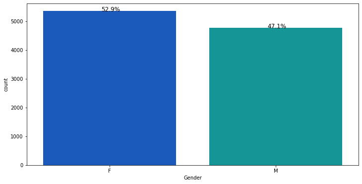

```python
# Plot barplot for Gender Variable
plt.figure(figsize=(12,6)) # set the figure size
ax = sns.countplot(data['Gender'],palette='winter')
perc_on_bar(ax,data['Gender'])
```

### Observations

- 53% of Thera banks credit card customers are of the female gender while 47% are male

### Visualization of Categorical Variables Using Barplot (Dependent_count)

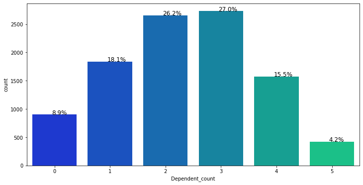

```python
# Plot barplot for Dependent_count Variable
plt.figure(figsize=(12,6)) # set the figure size
ax = sns.countplot(data['Dependent_count'],palette='winter')
perc_on_bar(ax,data['Dependent_count'])
```

### Observations

- About half of the banks customers have either 2(26%) or 3(27%) dependents
- 9% of customers have no dependents and 4% hav 5 dependents

### Visualization of Categorical Variables Using Barplot (Education_Level)

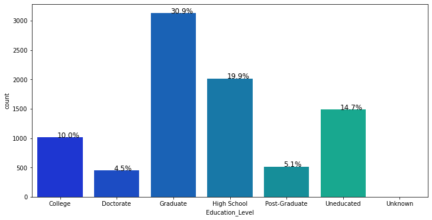

```python
# Plot barplot for Education_Level Variable
plt.figure(figsize=(12,6)) # set the figure size
ax = sns.countplot(data['Education_Level'],palette='winter')
perc_on_bar(ax,data['Education_Level'])
```

### Observations

- 31% of the banks credit card customers have graduate degrees, 20% of the customers are educated up to high school level, 10% have college degrees and 14.7% of customers are uneducated.
- Interestingly, customers that are highly educated(Post-Grad and Doctorate degrees) make up just 9.6% of the customer base.

### Visualization of Categorical Variables Using Barplot (Marital_Status)

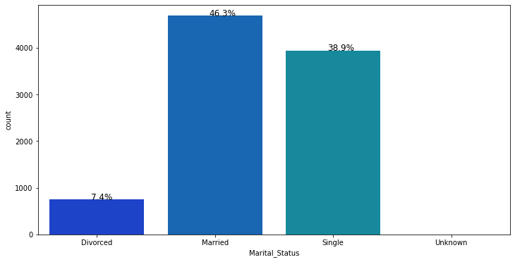

```python
# Plot barplot for Marital_Status Variable
plt.figure(figsize=(12,6)) # set the figure size
ax = sns.countplot(data['Marital_Status'],palette='winter')
perc_on_bar(ax,data['Marital_Status'])
```

### Observations

- Almost half (46%) of the banks credit card customers are married.

### Visualization of Categorical Variables Using Barplot (Income_Category)

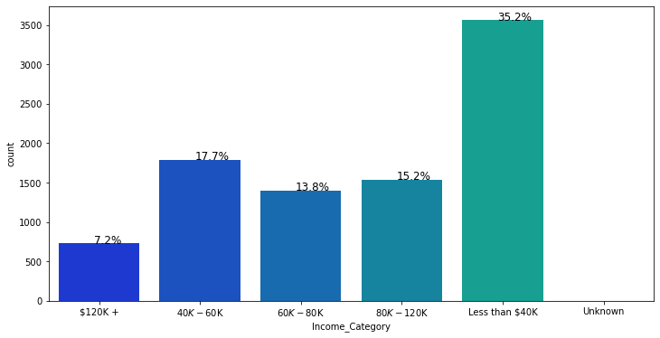

```python
# Plot barplot for Income_Category Variable
plt.figure(figsize=(12,6)) # set the figure size
ax = sns.countplot(data['Income_Category'],palette='winter')
perc_on_bar(ax,data['Income_Category'])
```

### Observations

- 35.2% of the banks credit card customers earn less than 40K annually with 7.2% earning over 120k annually

### Visualization of Categorical Variables Using Barplot (Card_Category)

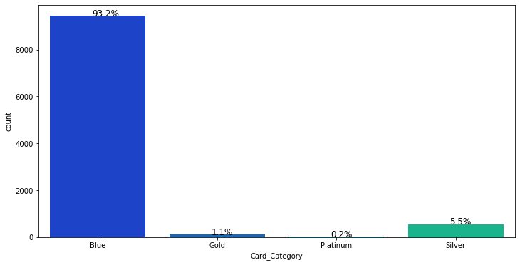

```python
# Plot barplot for Card_Category Variable
plt.figure(figsize=(12,6)) # set the figure size
ax = sns.countplot(data['Card_Category'],palette='winter')
perc_on_bar(ax,data['Card_Category'])
```

### Observations

- 93% of the banks customers are subscribed to te Blue card category. Given that most customers are low income earners and do not have advanced education, we can say that the Blue card category is the entry level product for the banks customers.

### Visualization of Categorical Variables Using Barplot (Total_Relationship_Count)

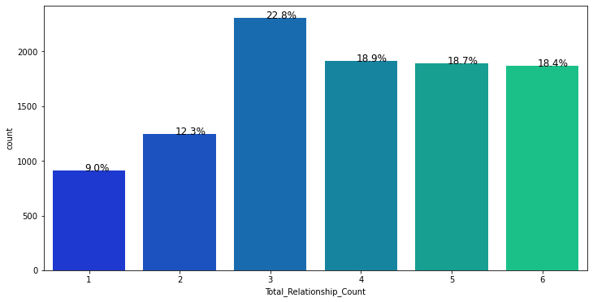

```python
# Plot barplot for Total_Relationship_Count Variable
plt.figure(figsize=(12,6)) # set the figure size
ax = sns.countplot(data['Total_Relationship_Count'],palette='winter')
perc_on_bar(ax,data['Total_Relationship_Count'])
```

### Observations

- 22.8% of customers have 3 products with the bank
- 18.9%, 18.7% and 18.4% of customers have 4,5 and 6 products with the bank respectively
- Just 9% of customers have 1 product with the bank

### Visualization of Categorical Variables Using Barplot (Months_Inactive_12_mon)

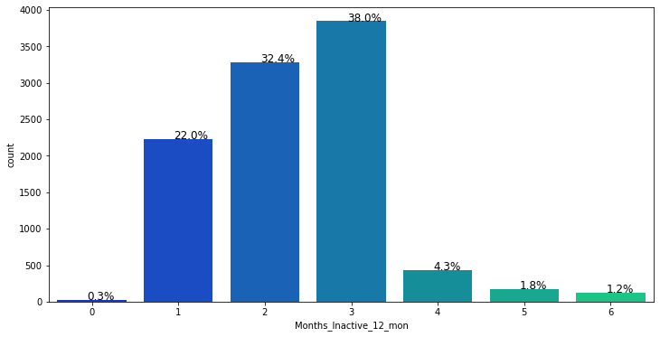

```python
# Plot barplot for Months_Inactive_12_mon Variable
plt.figure(figsize=(12,6)) # set the figure size
ax = sns.countplot(data['Months_Inactive_12_mon'],palette='winter')
perc_on_bar(ax,data['Months_Inactive_12_mon'])
```

### Observations

- 38% of customers were inactive for 3 months within the last 12 months. That is, these customers did not make use of their credit cards for 3 months within the last 12 months. It would be interesting to see if there is a relationship between card usage and attrition.

### Visualization of Categorical Variables Using Barplot (Contacts_Count_12_mon)

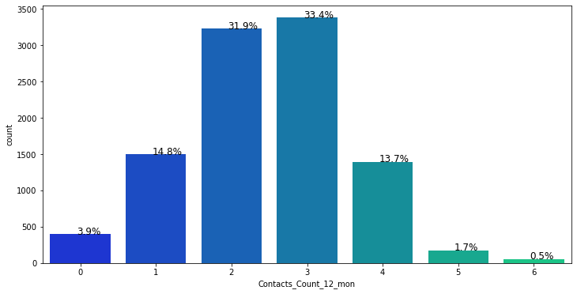

```python
# Plot barplot for Contacts_Count_12_mon Variable
plt.figure(figsize=(12,6)) # set the figure size
ax = sns.countplot(data['Contacts_Count_12_mon'],palette='winter')
perc_on_bar(ax,data['Contacts_Count_12_mon'])
```

### Observations

- In the last 12 months, most credit card customers made either 2(32%) or 3(33%) contacts to the bank

### 1.7 Exploratory Data Analysis (Bivariate Analysis)

### HeatMap

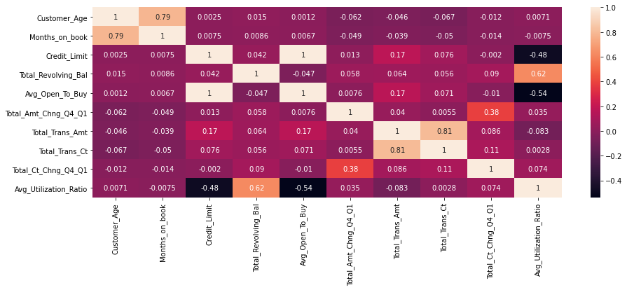

```python
# Diaplay Heatmap of numerical variables
plt.figure(figsize=(15,5))
sns.heatmap(data.corr(),annot=True)
plt.show()
```

### Pairplot

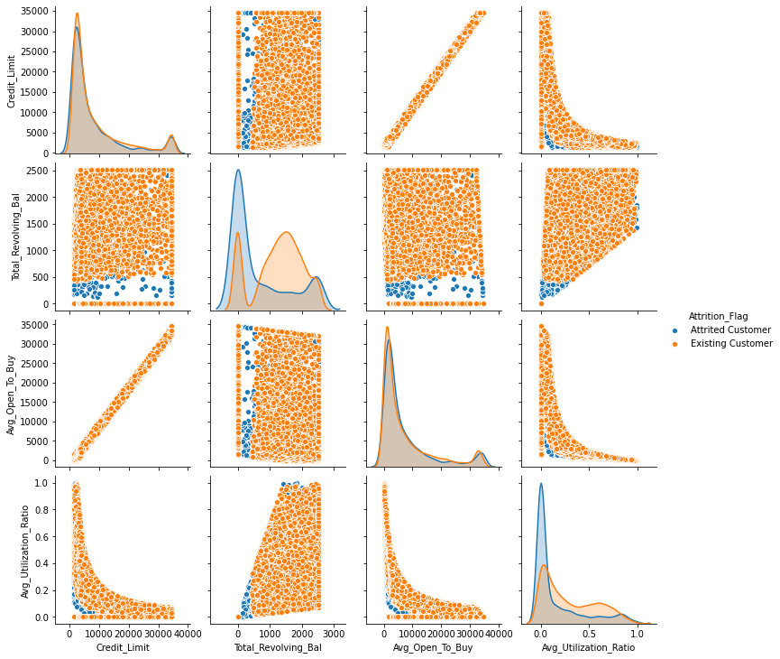

```python
#Scatterplot and distribution of some key numerical variables
colss = data[['Attrition_Flag','Credit_Limit','Total_Revolving_Bal','Avg_Open_To_Buy','Avg_Utilization_Ratio']]
sns.pairplot(data=colss,hue='Attrition_Flag')
```